# Regressão de Poisson Robusta

Análise de Dados Ambientais · Aula 19

Prof. Dr. Luiz Diego Vidal Santos

# POISSON ROBUSTA - TEORIA

## Estudos transversais e a medida de associação

Estudos transversais avaliam **exposição e desfecho em um único momento** - um dos delineamentos mais realizados em pesquisa.

A medida de associação correta é a **Razão de Prevalência (RP)**.

Calculada facilmente numa tabela 2×2:

$$RP = \frac{a/(a+b)}{c/(c+d)}$$

**O problema**

Quando é necessário **ajustar por confundidores**, muitos estudos utilizam regressão logística → obtêm **Odds Ratio (OR)**.

Porém OR e RP são calculados de maneiras diferentes e produzem **resultados diferentes**!

A OR tende a **superestimar** o efeito quando o desfecho é frequente.

Barros & Hirakata, 2003; Coutinho, Scazufca & Menezes, 2008

## RP vs. OR - por que importa?

### Exemplo numérico (tabela 2×2)

|  | Desfecho + | Desfecho − | Total |
| --- | --- | --- | --- |
| Exposto | 30 | 20 | 50 |
| Não exposto | 15 | 40 | 55 |
| **Total** | **45** | **60** | **105** |

$$RP = \frac{30/50}{15/55} = \frac{0{,}60}{0{,}27} = 2{,}2$$

$$OR = \frac{30 \times 40}{20 \times 15} = \frac{1200}{300} = 4{,}0$$

**Resultado:** RP = 2,2 vs. OR = 4,0

A OR quase **dobrou** a magnitude do efeito!

**Estudos de simulação mostram:**

| Frequência do desfecho | OR vs. RP |
| --- | --- |
| Baixa (< 10%) | Resultados semelhantes |
| Moderada (10-20%) | Superestimação |
| Alta (> 20%) | Superestimação expressiva |

Não é “errado” usar OR, mas a RP é a medida **correta** para estudos transversais.

Barros & Hirakata, 2003; Coutinho, Scazufca & Menezes, 2008

## Visualizando a divergência OR vs. RP

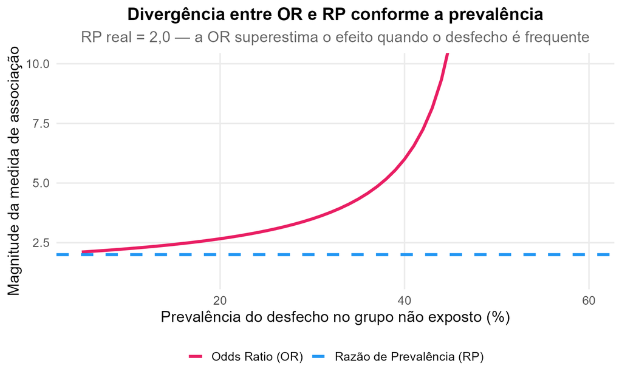

A OR diverge da RP conforme a prevalência do desfecho aumenta

**Interpretação do gráfico**

- A **RP real** é constante (2,0)
- A **OR** se afasta da RP quanto maior a prevalência
- Com prevalência > 20%, a OR já superestima substancialmente
- Com prevalência > 40%, a distorção é dramatica

Essa é a principal justificativa para **não usar** regressão logística em estudos transversais com desfechos frequentes.

## A solução: Poisson com variância robusta

O **estimador de variância robusta** (sanduíche de Huber-White) corrige esse problema.

**Vantagens**

- Sem dificuldade de convergência
- Resultados semelhantes ao Mantel-Haenszel (preditores categóricos)
- Interpretação direta como **Razão de Prevalência**
- Bem aceita na prática epidemiológica brasileira

**Características da Poisson Robusta**

- Segue o mesmo padrão da regressão de Poisson
- **Não há** necessidade de avaliar distribuição, variância ou dispersão
- **Não há** necessidade de comparar com binomial negativa
- Aceita preditores categóricos e numéricos
- Exp(B) = **Razão de Prevalência (RP)**
- Muito utilizada no Brasil

Barros & Hirakata, 2003; Coutinho, Scazufca & Menezes, 2008

# POISSON ROBUSTA - PRÁTICA

## Solicitando a análise

### No SPSS

`Analisar → GLM → Equações de Estimação Generalizadas (GEE)`

1. **Tipo de modelo:** Poisson loglinear
2. **Resposta:** variável dicotômica (0/1)
3. **Preditores:** fatores + covariáveis
4. **Estimação:** matriz de trabalho → robusta
5. Variável de identificação (ID do sujeito)

⚠️ No SPSS, a variância robusta é obtida via **GEE** (não via GLM padrão).

### No R

```r
library(sandwich)
library(lmtest)

# Ajustar Poisson padrão
modelo <- glm(desfecho ~ pred1 + pred2,
              data = dados,
              family = poisson(link = "log"))

# Erros-padrão robustos
coeftest(modelo, vcov = vcovHC(modelo,
                               type = "HC1"))

# RP com IC 95% robustos
exp(coef(modelo))
exp(confint(coeftest(modelo,
            vcov = vcovHC(modelo, "HC1"))))
```

## Interpretação da Razão de Prevalência

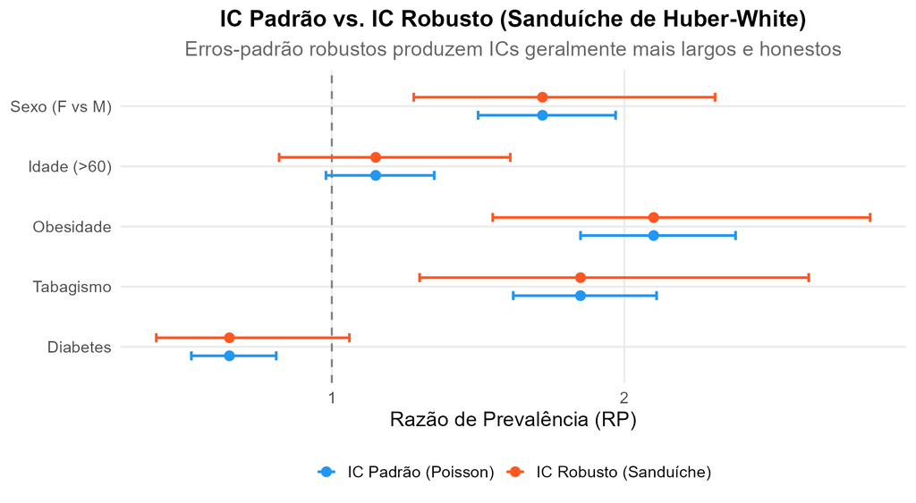

IC padrão vs. IC robusto (sanduíche de Huber-White)

**Regras de interpretação (RP)**

- **RP = 1** → prevalência **igual** entre grupos
- **RP < 1** → prevalência **menor** nos expostos (“proteção”)
- **RP > 1** → prevalência **maior** nos expostos (“risco”)

**Como quantificar:**

- **RP < 1:** faça 1 − RP
  - Ex.: RP = 0,65 → 35% menor
- **RP entre 1 e 2:** percentual
  - Ex.: RP = 1,38 → 38% maior
- **RP ≥ 2:** múltiplos
  - Ex.: RP = 2,50 → 2,5× mais prevalente

### Exemplo prático

# POISSON ROBUSTA - DESCRIÇÃO

## Como reportar

**Modelo de descrição para artigos/relatórios**

> “Para estimar a razão de prevalência (RP) com ajuste para variáveis confundidoras, utilizou-se a regressão de Poisson com estimador de variância robusta (sanduíche de Huber-White), por meio de Equações de Estimação Generalizadas (GEE) / Modelos Lineares Generalizados com erros-padrão robustos. Os resultados foram expressos por meio da RP com respectivos intervalos de confiança de 95%. O nível de significância adotado foi de 5%.”

### Estrutura do relatório

| Seção | O que incluir |
| --- | --- |
| **Método** | Poisson robusta, justificativa (estudo transversal), software |
| **Resultados** | RP, IC 95%, p-valor |
| **Tabela** | Preditores, B, RP, IC 95%, p |
| **Discussão** | Comparar RP com literatura; justificar a escolha sobre OR |

Barros & Hirakata, 2003; Coutinho, Scazufca & Menezes, 2008